# assignments_analysis.R

Lauren Shin

Thu Dec 14 10:56:09 2017

# Introduction

Data: assignments.csv  
Information from 104_datafiles.pdf about variables:  
**ASSIGNMENT**: the dependent variable, the final assignment chosen by a student:  
oral_exam vs. lab_report vs. thesis  
**SEX**: the sex of the student: female vs. male  
**REGION**: the geographical region of origin of the student:  
central_european vs. hispanic vs. middle_eastern  
**WORKHOURS**: the number of hours students self-report they invested into the course  
**MISTAKES**: the number of mistakes in the last test before choosing the assignment  
Overall question:  
Which independent variable(s) affect the assignment choice?

```r
rm(list=ls(all=TRUE)) # clear memory
```

setting the working directory, ie where data is  
works for local machine, will have to change for others’ though

```r
setwd("~/LING 104/assignments 1")
```

for making the trees later

```r
library(tree)
set.seed(42)
```

# Preliminary analysis of data

```r
summary(x <- read.delim("assignments.csv"))
```

```
##       CASE             ASSIGNMENT      SEX                   REGION
##  Min.   :  1.00   lab_report:100   female:145   central european: 99
##  1st Qu.: 75.75   oral_exam :100   male  :155   hispanic        :100
##  Median :150.50   thesis    :100                middle eastern  :101
##  Mean   :150.50
##  3rd Qu.:225.25
##  Max.   :300.00
##    WORKHOURS        MISTAKES
##  Min.   :12.10   Min.   :10.00
##  1st Qu.:19.77   1st Qu.:14.75
##  Median :29.90   Median :17.00
##  Mean   :27.34   Mean   :17.12
##  3rd Qu.:33.50   3rd Qu.:19.00
##  Max.   :39.90   Max.   :25.00
```

```r
# to make things easier to see in plots
colors <- c("dark blue", "dark green", "red")
```

## Simple plots

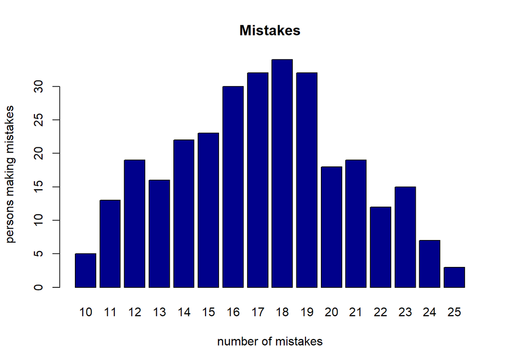

```r
barplot(table(x$MISTAKES),
        main = "Mistakes",
        ylab = "persons making mistakes",
        xlab = "number of mistakes",
        col = "dark blue")
```

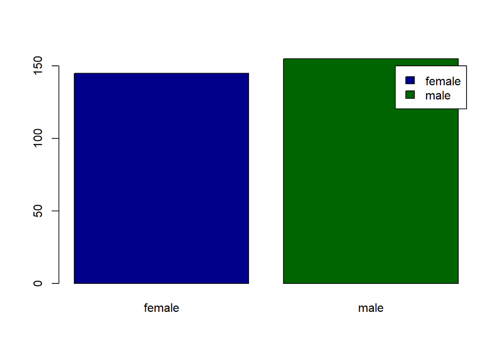

```r
# looks like a pretty normal distribution of mistakes

barplot(table(x$SEX), legend = TRUE, col = colors) # about half and half
```

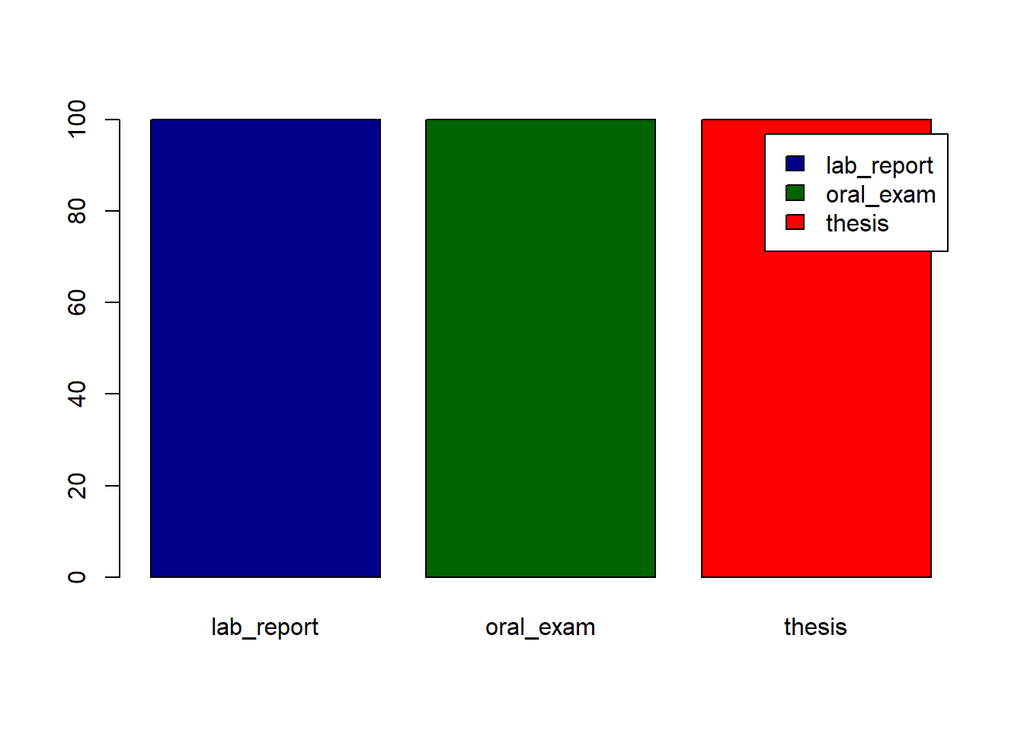

```r
barplot(table(x$ASSIGNMENT), legend = TRUE, col = colors) # pretty equally divided
```

```r
# so far nothing looks weird/particularly influential
```

## Sex

```r
table(x$ASSIGNMENT, x$SEX)
```

```
##
##              female male
##   lab_report     56   44
##   oral_exam      68   32
##   thesis         21   79
```

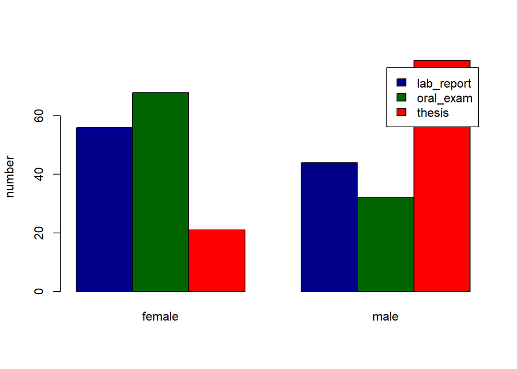

```r
# numbers look about even for lab_report
# but a lot more females chose to do a oral_exam than males
# and a lot more males chose to do a thesis than females
# easier to see it with a barplot
barplot(table(x$ASSIGNMENT, x$SEX),
        beside = TRUE,
        legend.text = TRUE,
        col = colors,
        ylab = "number")
```

## Region

```r
table(x$ASSIGNMENT, x$REGION)
```

```
##
##              central european hispanic middle eastern
##   lab_report               18       14             68
##   oral_exam                70       18             12
##   thesis                   11       68             21
```

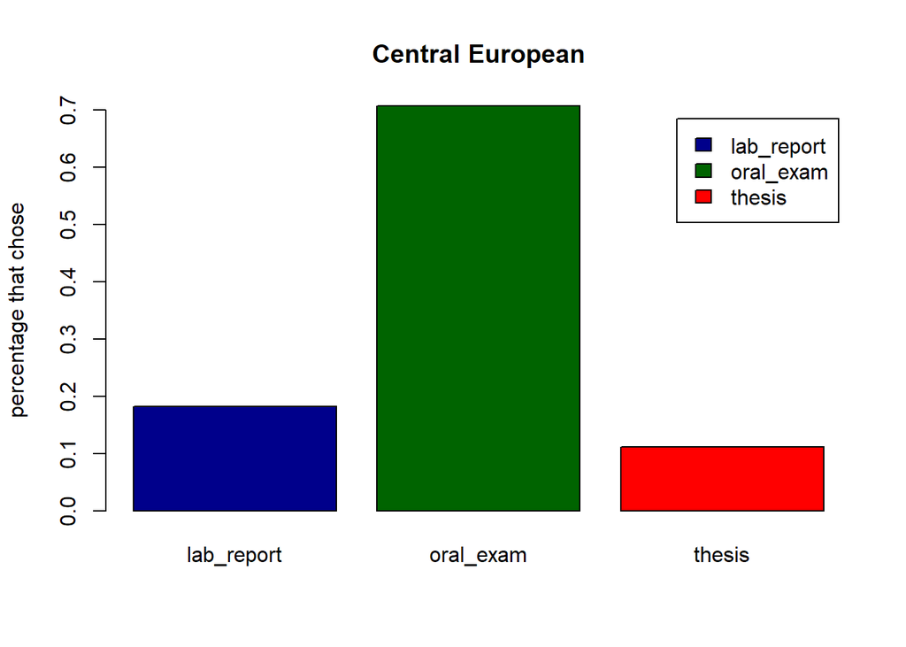

```r
# sort of unclear, lots of things going on

barplot(prop.table(table(x$REGION, x$ASSIGNMENT)[1,]),
        legend.text = TRUE,
        col = colors,
        main = "Central European",
        ylab = "percentage that chose")
```

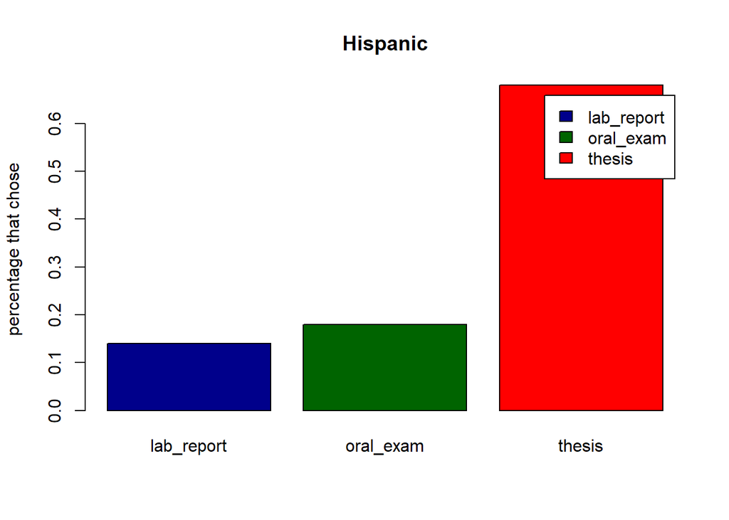

```r
barplot(prop.table(table(x$REGION, x$ASSIGNMENT)[2,]),
        legend.text = TRUE,
        col = colors,
        main = "Hispanic",
        ylab = "percentage that chose")
```

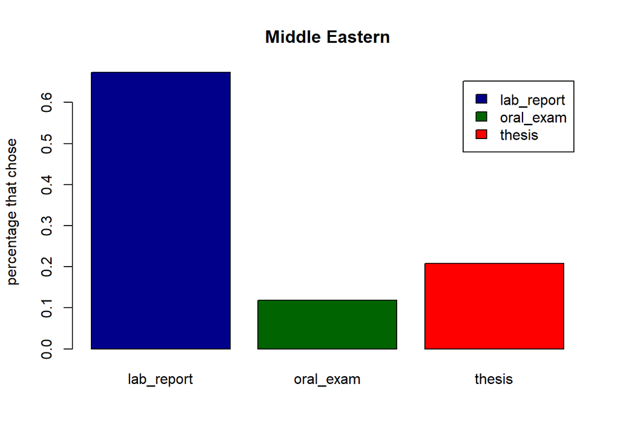

```r
barplot(prop.table(table(x$REGION, x$ASSIGNMENT)[3,]),
        legend.text = TRUE,
        col = colors,
        main = "Middle Eastern",
        ylab = "percentage that chose")
```

```r
# each group has a spike in numbers in a separate format
# ie, oral exam for CE, thesis for H, and lab report for ME
```

## Workhours

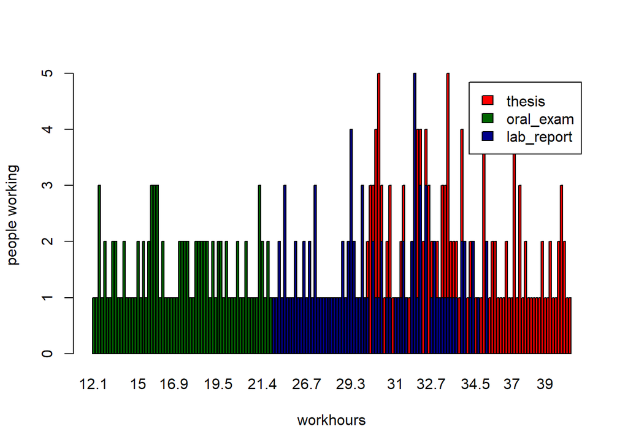

```r
# plotting against assignment shows a general trend
barplot(table(x$ASSIGNMENT,
              x$WORKHOURS),
        ylab = "people working",
        xlab = "workhours",
        col = colors,
        legend =TRUE)
```

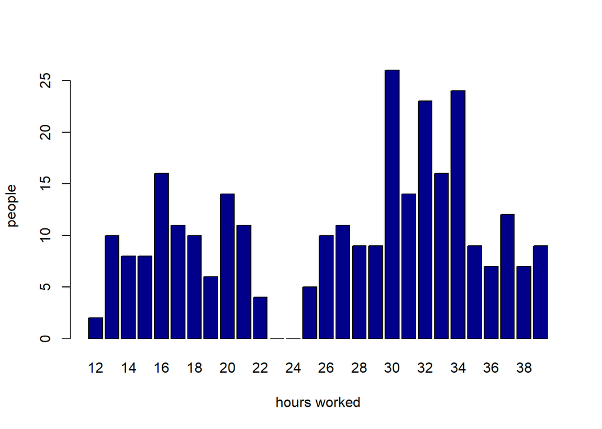

```r
# lower work hours correlated to oral exams, while high workhours to thesis
# middle work hours correlated to lab report

# plotting simplified (by integer, not exact decimal) workhour data
barplot(table(factor(round(x$WORKHOURS), levels=12:39)),
        ylab = "people",
        xlab = "hours worked",
        col = "dark blue")
```

Weird gap from 22-24? May be two separate distributions.  
##Mistakes

```r
table(x$ASSIGNMENT, x$MISTAKES)
```

```
##
##              10 11 12 13 14 15 16 17 18 19 20 21 22 23 24 25
##   lab_report  0  0  7  6 12  9 11 14  9  8  7 14  3  0  0  0
##   oral_exam   5 13 12 10 10  9  7  8  9 10  7  0  0  0  0  0
##   thesis      0  0  0  0  0  5 12 10 16 14  4  5  9 15  7  3
```

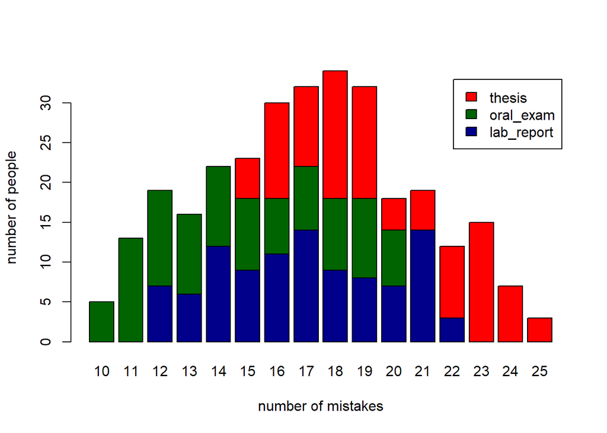

```r
# 0s appear in interesting places
# easier to see with a plot
barplot(table(x$ASSIGNMENT, x$MISTAKES),
        legend.text = TRUE,
        ylab = "number of people",
        xlab = "number of mistakes",
        col = colors)
```

```r
# shows the distribution of colors/assignment types over number of mistakes made
```

### Overall

```r
attach(x)
```

# Creating the tree

```r
summary(cart.1 <- tree(ASSIGNMENT ~ SEX+REGION+WORKHOURS+MISTAKES))
```

```
##
## Classification tree:
## tree(formula = ASSIGNMENT ~ SEX + REGION + WORKHOURS + MISTAKES)
## Number of terminal nodes:  8
## Residual mean deviance:  0.3266 = 95.35 / 292
## Misclassification error rate: 0.08 = 24 / 300
```

## Classification accuracy

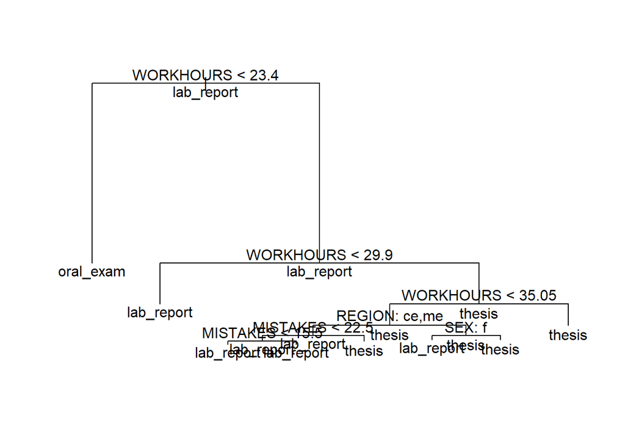

```r
predictions.num <- predict(cart.1)
predictions.cat <- predict(cart.1, type = "class")

# this is really, really messy
plot(cart.1)
    text(cart.1, pretty=1, all=TRUE)
```

```r
# but first three nodes from the top all involve workhours, probably important
# harder to see all the terminal nodes, hopefully it can be simplified later

# actual versus prediction
table(ASSIGNMENT, predictions.cat)
```

```
##             predictions.cat
## ASSIGNMENT   lab_report oral_exam thesis
##   lab_report         97         0      3
##   oral_exam           0       100      0
##   thesis             21         0     79
```

```r
# accuracy:
(97+100+79) / length(predictions.cat)
```

```
## [1] 0.92
```

```r
# main diagonal of previous table added up
# accuracy looks pretty good
```

## Making training/testing set to apply to data

```r
sampler <- sample(rep(c("training", "test"), c(225, 75)))

# tree from training data
cart.validation.training <- tree(formula(cart.1),
         data=x[sampler=="training",])

# making predictions for test data based on training data
predictions.validation.test <- predict(cart.validation.training,
            newdata=x[sampler=="test",],
            type="class")

# percentage of times the predictions matched the actual data
sum(predictions.validation.test ==
        ASSIGNMENT[sampler=="test"]) /
    length(predictions.validation.test)
```

```
## [1] 0.8533333
```

```r
# seems good
```